```python
import pandas as pd #Importing Pandas library
import os #Importing Pandas library
from matplotlib import pyplot as plt
```

# 1) Write a python program to merge data from each month into one CSV and read in updated dataframe.

```python
## data preperation For extraction
```

```python
path = './Sales_Analysis/CSV/'
for files in os.listdir(path):
    print(files)
DataFrame = pd.DataFrame()
for files in os.listdir(path):
    df = pd.read_csv(path+files)
    DataFrame = pd.concat([DataFrame,df])
```

```
Sales_April_2019.csv
Sales_August_2019.csv
Sales_December_2019.csv
Sales_February_2019.csv
Sales_January_2019.csv
Sales_July_2019.csv
Sales_June_2019.csv
Sales_March_2019.csv
Sales_May_2019.csv
Sales_November_2019.csv
Sales_October_2019.csv
Sales_September_2019.csv
```

```python
##Python program to read Data Frame.
```

```python
DataFrame
```

|  | Order ID | Product | Quantity Ordered | Price Each | Order Date | Purchase Address |
| --- | --- | --- | --- | --- | --- | --- |
| 0 | 176558.0 | USB-C Charging Cable | 2.0 | 11.95 | 4/19/2019 8:46 | 917 1st St, Dallas, TX 75001 |
| 1 | NaN | NaN | NaN | NaN | NaN | NaN |
| 2 | 176559.0 | Bose SoundSport Headphones | 1.0 | 99.99 | 4/7/2019 22:30 | 682 Chestnut St, Boston, MA 02215 |
| 3 | 176560.0 | Google Phone | 1.0 | 600.00 | 4/12/2019 14:38 | 669 Spruce St, Los Angeles, CA 90001 |
| 4 | 176560.0 | Wired Headphones | 1.0 | 11.99 | 4/12/2019 14:38 | 669 Spruce St, Los Angeles, CA 90001 |
| ... | ... | ... | ... | ... | ... | ... |
| 11681 | 259353.0 | AAA Batteries (4-pack) | 3.0 | 2.99 | 9/17/2019 20:56 | 840 Highland St, Los Angeles, CA 90001 |
| 11682 | 259354.0 | iPhone | 1.0 | 700.00 | 9/1/2019 16:00 | 216 Dogwood St, San Francisco, CA 94016 |
| 11683 | 259355.0 | iPhone | 1.0 | 700.00 | 9/23/2019 7:39 | 220 12th St, San Francisco, CA 94016 |
| 11684 | 259356.0 | 34in Ultrawide Monitor | 1.0 | 379.99 | 9/19/2019 17:30 | 511 Forest St, San Francisco, CA 94016 |
| 11685 | 259357.0 | USB-C Charging Cable | 1.0 | 11.95 | 9/30/2019 0:18 | 250 Meadow St, San Francisco, CA 94016 |

186850 rows × 6 columns

```python
DataFrame.info()
```

```
<class 'pandas.core.frame.DataFrame'>
Int64Index: 186850 entries, 0 to 11685
Data columns (total 6 columns):
 #   Column            Non-Null Count   Dtype
---  ------            --------------   -----
 0   Order ID          185950 non-null  float64
 1   Product           185950 non-null  object
 2   Quantity Ordered  185950 non-null  float64
 3   Price Each        185950 non-null  float64
 4   Order Date        185950 non-null  object
 5   Purchase Address  185950 non-null  object
dtypes: float64(3), object(3)
memory usage: 10.0+ MB
```

# 2) Write a python program to remove the NaN missing values from updated dataframe

```python
## Removing the NaN Missing value From udated dataframe.
```

```python
DataFrame = DataFrame.dropna()
```

```python
DataFrame
```

|  | Order ID | Product | Quantity Ordered | Price Each | Order Date | Purchase Address |
| --- | --- | --- | --- | --- | --- | --- |
| 0 | 176558.0 | USB-C Charging Cable | 2.0 | 11.95 | 4/19/2019 8:46 | 917 1st St, Dallas, TX 75001 |
| 2 | 176559.0 | Bose SoundSport Headphones | 1.0 | 99.99 | 4/7/2019 22:30 | 682 Chestnut St, Boston, MA 02215 |
| 3 | 176560.0 | Google Phone | 1.0 | 600.00 | 4/12/2019 14:38 | 669 Spruce St, Los Angeles, CA 90001 |
| 4 | 176560.0 | Wired Headphones | 1.0 | 11.99 | 4/12/2019 14:38 | 669 Spruce St, Los Angeles, CA 90001 |
| 5 | 176561.0 | Wired Headphones | 1.0 | 11.99 | 4/30/2019 9:27 | 333 8th St, Los Angeles, CA 90001 |
| ... | ... | ... | ... | ... | ... | ... |
| 11681 | 259353.0 | AAA Batteries (4-pack) | 3.0 | 2.99 | 9/17/2019 20:56 | 840 Highland St, Los Angeles, CA 90001 |
| 11682 | 259354.0 | iPhone | 1.0 | 700.00 | 9/1/2019 16:00 | 216 Dogwood St, San Francisco, CA 94016 |
| 11683 | 259355.0 | iPhone | 1.0 | 700.00 | 9/23/2019 7:39 | 220 12th St, San Francisco, CA 94016 |
| 11684 | 259356.0 | 34in Ultrawide Monitor | 1.0 | 379.99 | 9/19/2019 17:30 | 511 Forest St, San Francisco, CA 94016 |
| 11685 | 259357.0 | USB-C Charging Cable | 1.0 | 11.95 | 9/30/2019 0:18 | 250 Meadow St, San Francisco, CA 94016 |

185950 rows × 6 columns

# 3) Write a python program to convert Quantity Ordered and Price Each to numeric.

```python
## Write a program to convert Quantity Ordered and Price Each to numeric.
```

```python
DataFrame['Quantity Ordered'] =pd.to_numeric(DataFrame['Quantity Ordered'])
DataFrame['Price Each'] =pd.to_numeric(DataFrame['Price Each'])
DataFrame
```

|  | Order ID | Product | Quantity Ordered | Price Each | Order Date | Purchase Address |
| --- | --- | --- | --- | --- | --- | --- |
| 0 | 176558.0 | USB-C Charging Cable | 2.0 | 11.95 | 4/19/2019 8:46 | 917 1st St, Dallas, TX 75001 |
| 2 | 176559.0 | Bose SoundSport Headphones | 1.0 | 99.99 | 4/7/2019 22:30 | 682 Chestnut St, Boston, MA 02215 |
| 3 | 176560.0 | Google Phone | 1.0 | 600.00 | 4/12/2019 14:38 | 669 Spruce St, Los Angeles, CA 90001 |
| 4 | 176560.0 | Wired Headphones | 1.0 | 11.99 | 4/12/2019 14:38 | 669 Spruce St, Los Angeles, CA 90001 |
| 5 | 176561.0 | Wired Headphones | 1.0 | 11.99 | 4/30/2019 9:27 | 333 8th St, Los Angeles, CA 90001 |
| ... | ... | ... | ... | ... | ... | ... |
| 11681 | 259353.0 | AAA Batteries (4-pack) | 3.0 | 2.99 | 9/17/2019 20:56 | 840 Highland St, Los Angeles, CA 90001 |
| 11682 | 259354.0 | iPhone | 1.0 | 700.00 | 9/1/2019 16:00 | 216 Dogwood St, San Francisco, CA 94016 |
| 11683 | 259355.0 | iPhone | 1.0 | 700.00 | 9/23/2019 7:39 | 220 12th St, San Francisco, CA 94016 |
| 11684 | 259356.0 | 34in Ultrawide Monitor | 1.0 | 379.99 | 9/19/2019 17:30 | 511 Forest St, San Francisco, CA 94016 |
| 11685 | 259357.0 | USB-C Charging Cable | 1.0 | 11.95 | 9/30/2019 0:18 | 250 Meadow St, San Francisco, CA 94016 |

185950 rows × 6 columns

# 4) Create a new column named Month from Ordered Date of updated dataframe and convert it to integer as data type.

```python
##  Create a new column named Month from Ordered Date of updated dataframe and convert it to integer as data type.
```

```python
DataFrame['Month'] = DataFrame['Order Date'].str.split('/').str[0].astype(int)
DataFrame
```

[output not shown]

```python
DataFrame['Month'].dtype
```

```
dtype('int32')
```

# 5) Create a new column named City from Purchase Address based on the value in updated dataframe

```python
##Create a new column named City from Purchase Address based on the value in updated dataframe.
```

```python
DataFrame['City'] = DataFrame['Purchase Address'].str.split(',').str[1]
DataFrame
```

|  | Order ID | Product | Quantity Ordered | Price Each | Order Date | Purchase Address | Month | City |
| --- | --- | --- | --- | --- | --- | --- | --- | --- |
| 0 | 176558.0 | USB-C Charging Cable | 2.0 | 11.95 | 4/19/2019 8:46 | 917 1st St, Dallas, TX 75001 | 4 | Dallas |
| 2 | 176559.0 | Bose SoundSport Headphones | 1.0 | 99.99 | 4/7/2019 22:30 | 682 Chestnut St, Boston, MA 02215 | 4 | Boston |
| 3 | 176560.0 | Google Phone | 1.0 | 600.00 | 4/12/2019 14:38 | 669 Spruce St, Los Angeles, CA 90001 | 4 | Los Angeles |
| 4 | 176560.0 | Wired Headphones | 1.0 | 11.99 | 4/12/2019 14:38 | 669 Spruce St, Los Angeles, CA 90001 | 4 | Los Angeles |
| 5 | 176561.0 | Wired Headphones | 1.0 | 11.99 | 4/30/2019 9:27 | 333 8th St, Los Angeles, CA 90001 | 4 | Los Angeles |
| ... | ... | ... | ... | ... | ... | ... | ... | ... |
| 11681 | 259353.0 | AAA Batteries (4-pack) | 3.0 | 2.99 | 9/17/2019 20:56 | 840 Highland St, Los Angeles, CA 90001 | 9 | Los Angeles |
| 11682 | 259354.0 | iPhone | 1.0 | 700.00 | 9/1/2019 16:00 | 216 Dogwood St, San Francisco, CA 94016 | 9 | San Francisco |
| 11683 | 259355.0 | iPhone | 1.0 | 700.00 | 9/23/2019 7:39 | 220 12th St, San Francisco, CA 94016 | 9 | San Francisco |
| 11684 | 259356.0 | 34in Ultrawide Monitor | 1.0 | 379.99 | 9/19/2019 17:30 | 511 Forest St, San Francisco, CA 94016 | 9 | San Francisco |
| 11685 | 259357.0 | USB-C Charging Cable | 1.0 | 11.95 | 9/30/2019 0:18 | 250 Meadow St, San Francisco, CA 94016 | 9 | San Francisco |

185950 rows × 8 columns

# 6) Write a Python program to show summary statistics of sum, mean, standard deviation, skewness, and kurtosis of any chosen variable

```python
##Python program to show summary statistics of sum, mean, standard deviation, skewness, and kurtosis of any chosen variable.
```

```python
Quantity_sum =DataFrame['Quantity Ordered'].sum()##Using .sum() function
Quantity_mean =DataFrame['Quantity Ordered'].mean()##Using .mean() function
Quantity_std =DataFrame['Quantity Ordered'].std()##Using .std() function
Quantity_skew =DataFrame['Quantity Ordered'].skew()##Using .skew() function
Quantity_kurt =DataFrame['Quantity Ordered'].kurt()##Using .kurt() function
```

```python
print("The summary statistics of sum, mean, standard deviation, skewness, and kurtosis of Quantity Ordered are:")
print('--------------------------------------------------------------------------------------------------------')
print('Sum:',Quantity_sum)
print("Mean:",Quantity_mean,)
print("Standard:",Quantity_std)
print("SKewness:",Quantity_skew)
print("Kurtosis",Quantity_kurt)
```

```
The summary statistics of sum, mean, standard deviation, skewness, and kurtosis of Quantity Ordered are:
--------------------------------------------------------------------------------------------------------
Sum: 209079.0
Mean: 1.1243828986286637
Standard: 0.44279262402849096
SKewness: 4.833164172577953
Kurtosis 31.82048892027536
```

# 7) Write a Python program to calculate and show correlation of all variables.

```python
##Write a Python program to calculate and show correlation of all variables.
```

```python
# calculate correlation matrix
DataFrame.corr()##Using .corr() function
```

|  | Order ID | Quantity Ordered | Price Each | Month |
| --- | --- | --- | --- | --- |
| Order ID | 1.000000 | 0.000702 | -0.002857 | 0.993063 |
| Quantity Ordered | 0.000702 | 1.000000 | -0.148272 | 0.000791 |
| Price Each | -0.002857 | -0.148272 | 1.000000 | -0.003375 |
| Month | 0.993063 | 0.000791 | -0.003375 | 1.000000 |

# 8) Which Month has the best sales? and how much was the earning in that month? Make a bar graph of sales as well.

```python
##Which Month has the best sales?
```

```python
DataFrame['Sales'] = DataFrame['Quantity Ordered']* DataFrame['Price Each']
DataFrame
```

[output not shown]

```python
monthly = DataFrame.groupby('Month')['Sales'].sum()
monthly
```

```
Month
1     1822256.73
2     2202022.42
3     2807100.38
4     3390670.24
5     3152606.75
6     2577802.26
7     2647775.76
8     2244467.88
9     2097560.13
10    3736726.88
11    3199603.20
12    4613443.34
Name: Sales, dtype: float64
```

```python
best_Sales_month = monthly.idxmax()
best_Sales_month
```

```
12
```

```python
##how much was the earning in that month?
```

```python
best_sales = monthly.max()
best_sales
```

```
4613443.34
```

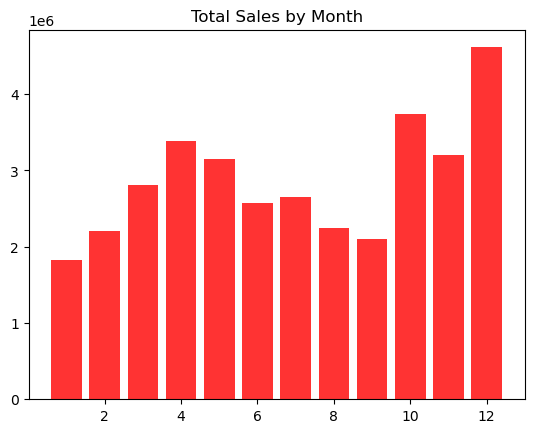

```python
# sort the monthly sales by month in ascending order
monthly = monthly.sort_index()

# create a bar graph of the monthly sales

plt.bar(monthly.index, monthly.values, color='Red', alpha=0.8)

# add a title to the plot
plt.title("Total Sales by Month")

# show the plot
plt.show()
```

# 9) Which city has sold the highest product?

```python
## Which city has sold the highest product?
```

```python
city_sales = DataFrame.groupby('City')['Sales'].sum().sort_values(ascending=False)
max_sales_city = city_sales.idxmax()
max_sales_city
```

```
' San Francisco'
```

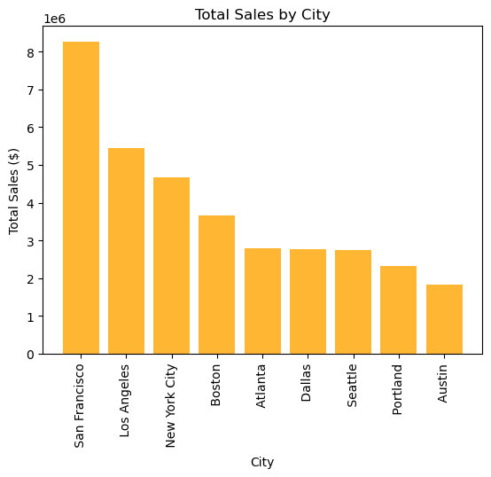

```python
# Create a bar plot of the total sales by city
plt.bar(city_sales.index, city_sales.values, color='orange' ,alpha=0.8)
plt.title('Total Sales by City')
plt.xlabel('City')
plt.ylabel('Total Sales ($)')
plt.xticks(rotation=90)##
plt.show()
```

# 10) Which product was sold the most in overall? Illustrate it through bar graph.

```python
## Which product was sold the most in overall?
```

```python
product = DataFrame.groupby('Product')['Sales'].sum().sort_values(ascending=False)
most_sold_product = product.idxmax()
most_sold_product
```

```
'Macbook Pro Laptop'
```

```python
##Illustrate it through bar graph.
```

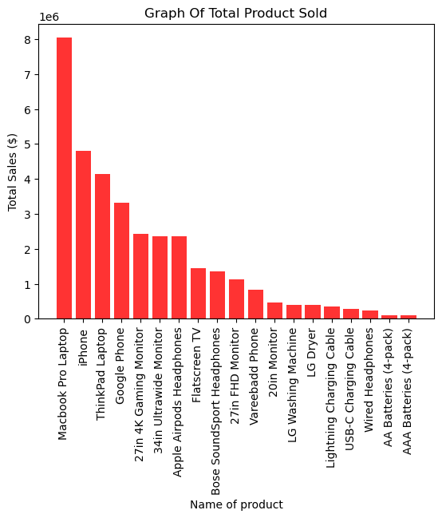

```python
plt.bar(product.index, product.values, color='red' ,alpha=0.8)
plt.title('Graph Of Total Product Sold')
plt.xlabel('Name of product')
plt.ylabel('Total Sales ($)')
plt.xticks(rotation=90)
plt.show()
```

# 11) Write a Python program to show histogram plot of any chosen variables. Use proper labels in the graph

```python
## Write a Python program to show histogram plot of any chosen variables. Use proper labels in the graph.
```

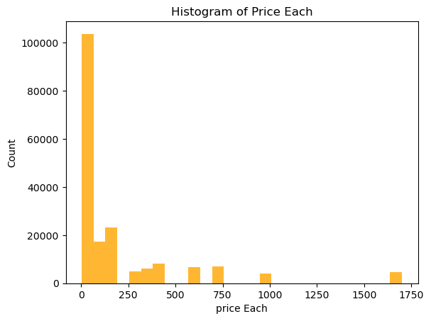

```python
plt.hist(DataFrame['Price Each'], bins=27, color='orange', alpha=0.8)
plt.title('Histogram of Price Each')
plt.xlabel("price Each")
plt.ylabel('Count')
plt.show()
```